# Model 2: Mixed effects ordinal regression (stacked data)

## Preprocessing

A few tweaks had to be made to some predictors -namely word count, that was making the model unstable. Basically, it was recoded to 500 words, 500-1000 words or above 1000 words. This all makes sense and makes it more interpretable than saying a change of 1 word has X effect on the probability. The variable is called “words”.

Also, visibility -which was very skewed- has 3 categories with a much better distribution:

1. Very low
2. Low to medium
3. High/Very high

Visibility is called “vis4” in the models.

Let’s start with a few story level predictors in a mixed effects ordinal regression.

## Model 1

#### Summary

In the summary output, the main coefficients are the fixed effects.

In the summary output, you can see the model specification the formula line.

We can see that only “words” and “vis4” are signficant. “vis4” is ordinaly, and it’s the change from Very Low to Low-Medium that is significant.

```
Cumulative Link Mixed Model fitted with the Laplace approximation

formula: Tone ~ vis4 + words + year2 + sourceFormat + (1 | country) +
    (1 | site)
data:    df

 link  threshold nobs logLik  AIC     niter     max.grad cond.H
 logit flexible  984  -945.15 1910.30 767(3071) 4.88e-04 6.8e+01

Random effects:
 Groups  Name        Variance Std.Dev.
 site    (Intercept) 0.6781   0.8235
 country (Intercept) 0.3540   0.5950
Number of groups:  site 227,  country 8

Coefficients:
                        Estimate Std. Error z value Pr(>|z|)
vis4.L                  -0.56246    0.13642  -4.123 3.74e-05 ***
vis4.Q                   0.13500    0.12054   1.120  0.26276
words500-1000           -0.44543    0.15604  -2.855  0.00431 **
words+1000              -1.36981    0.26728  -5.125 2.98e-07 ***
year2                   -0.11287    0.09941  -1.135  0.25622
sourceFormatOnline only  0.21875    0.20189   1.084  0.27858
---
Signif. codes:  0 '***' 0.001 '**' 0.01 '*' 0.05 '.' 0.1 ' ' 1

Threshold coefficients:
                 Estimate Std. Error z value
Negative|Neutral  -1.8558     0.3459  -5.365
Neutral|Positive  -0.2504     0.3390  -0.739
(1 observation deleted due to missingness)
```

## Model 2

In model 2 we’ll add some country attributes (Netpayer and Level). We can see that only Level appears to be signficiant.

### Summary model 2

```
Cumulative Link Mixed Model fitted with the Laplace approximation

formula: Tone ~ level + NetPayer + vis4 + words + year2 + sourceFormat +
    (1 | country) + (1 | site)
data:    df

 link  threshold nobs logLik  AIC     niter      max.grad cond.H
 logit flexible  984  -937.71 1899.42 1038(4156) 1.54e-03 1.5e+02

Random effects:
 Groups  Name        Variance Std.Dev.
 site    (Intercept) 0.5924   0.7697
 country (Intercept) 0.3006   0.5482
Number of groups:  site 227,  country 8

Coefficients:
                        Estimate Std. Error z value Pr(>|z|)
levelNational           -0.74028    0.20171  -3.670 0.000243 ***
NetPayerYes             -0.49793    0.44650  -1.115 0.264769
vis4.L                  -0.53597    0.13617  -3.936 8.28e-05 ***
vis4.Q                   0.16787    0.12021   1.397 0.162556
words500-1000           -0.40462    0.15528  -2.606 0.009166 **
words+1000              -1.35664    0.26618  -5.097 3.46e-07 ***
year2                   -0.11068    0.09873  -1.121 0.262294
sourceFormatOnline only  0.34574    0.20068   1.723 0.084908 .
---
Signif. codes:  0 '***' 0.001 '**' 0.01 '*' 0.05 '.' 0.1 ' ' 1

Threshold coefficients:
                 Estimate Std. Error z value
Negative|Neutral  -2.5910     0.4565  -5.676
Neutral|Positive  -0.9826     0.4477  -2.195
(1 observation deleted due to missingness)
```

## Model 3

In model 3 we will now add the Frames variable (Economics vs Politics frame), called “dim” in the model.

### Summary model 3

Here we can see the effect of including Frames. It has a huge coefficient. Moving from an Economics frame to Politics frame is nearly 15 times more likely to be associated with negative tone (that’s the odds ratio for a logit value of ~2.7).

We can also see that virtually everything else drops out.

```
Cumulative Link Mixed Model fitted with the Laplace approximation

formula:
Tone ~ dim + level + NetPayer + vis4 + words + year2 + sourceFormat +
    (1 | country) + (1 | site)
data:    df

 link  threshold nobs logLik  AIC     niter      max.grad cond.H
 logit flexible  984  -805.72 1637.44 1247(4991) 5.92e-04 1.3e+02

Random effects:
 Groups  Name        Variance Std.Dev.
 site    (Intercept) 0.7645   0.8743
 country (Intercept) 0.2295   0.4791
Number of groups:  site 227,  country 8

Coefficients:
                        Estimate Std. Error z value Pr(>|z|)
dimPolitics             -2.69735    0.18921 -14.256  < 2e-16 ***
levelNational           -0.28110    0.21965  -1.280  0.20063
NetPayerYes             -0.04219    0.41253  -0.102  0.91855
vis4.L                  -0.02982    0.14922  -0.200  0.84162
vis4.Q                   0.23344    0.12906   1.809  0.07050 .
words500-1000           -0.51030    0.16895  -3.020  0.00252 **
words+1000              -1.14317    0.28763  -3.974 7.05e-05 ***
year2                   -0.12669    0.10717  -1.182  0.23716
sourceFormatOnline only  0.08581    0.22052   0.389  0.69718
---
Signif. codes:  0 '***' 0.001 '**' 0.01 '*' 0.05 '.' 0.1 ' ' 1

Threshold coefficients:
                 Estimate Std. Error z value
Negative|Neutral  -3.7462     0.4651  -8.055
Neutral|Positive  -1.6653     0.4452  -3.741
(1 observation deleted due to missingness)
```

## Model 4

Let’s add some interaction effects to the model. This can be seen in the summary output below.

### Summary model 4

Here we can see most interqaction effects are signficant. Probably because of the powerful effect of the Frame.

```
Cumulative Link Mixed Model fitted with the Laplace approximation

formula:
Tone ~ dim * (level + NetPayer + words + vis4) + year2 + sourceFormat +
    (1 | country) + (1 | site)
data:    df

 link  threshold nobs logLik  AIC     niter      max.grad cond.H
 logit flexible  984  -785.99 1609.97 1985(6081) 2.65e-03 1.9e+02

Random effects:
 Groups  Name        Variance Std.Dev.
 site    (Intercept) 0.7945   0.8913
 country (Intercept) 0.2004   0.4476
Number of groups:  site 227,  country 8

Coefficients:
                          Estimate Std. Error z value Pr(>|z|)
dimPolitics                -4.8995     0.4625 -10.594  < 2e-16 ***
levelNational              -0.6438     0.2745  -2.345  0.01900 *
NetPayerYes                -0.6000     0.4239  -1.415  0.15701
words500-1000              -0.9306     0.2295  -4.055 5.01e-05 ***
words+1000                 -1.7240     0.4162  -4.142 3.44e-05 ***
vis4.L                     -0.2418     0.2164  -1.118  0.26374
vis4.Q                      0.3435     0.1865   1.842  0.06549 .
year2                      -0.1074     0.1090  -0.986  0.32437
sourceFormatOnline only     0.1455     0.2257   0.645  0.51924
dimPolitics:levelNational   0.9159     0.3588   2.553  0.01069 *
dimPolitics:NetPayerYes     1.4599     0.3599   4.057 4.98e-05 ***
dimPolitics:words500-1000   1.0376     0.3231   3.212  0.00132 **
dimPolitics:words+1000      1.1972     0.5641   2.122  0.03382 *
dimPolitics:vis4.L          0.5755     0.2917   1.973  0.04854 *
dimPolitics:vis4.Q         -0.2459     0.2635  -0.933  0.35088
---
Signif. codes:  0 '***' 0.001 '**' 0.01 '*' 0.05 '.' 0.1 ' ' 1

Threshold coefficients:
                 Estimate Std. Error z value
Negative|Neutral  -4.4842     0.4941  -9.075
Neutral|Positive  -2.3383     0.4701  -4.974
(1 observation deleted due to missingness)
```

Is the complicated model Model 4 better than Model 3. The model 4 AIC is lower than model 3. The anova comparison of models suggest they are significantly different, leading us to prefer Model 4.

```
Likelihood ratio tests of cumulative link models:

   formula:
m3 Tone ~ dim + level + NetPayer + vis4 + words + year2 + sourceFormat + (1 | country) + (1 | site)
m4 Tone ~ dim * (level + NetPayer + words + vis4) + year2 + sourceFormat + (1 | country) + (1 | site)
   link: threshold:
m3 logit flexible
m4 logit flexible

   no.par    AIC  logLik LR.stat df Pr(>Chisq)
m3     13 1637.4 -805.72
m4     19 1610.0 -785.99  39.473  6  5.781e-07 ***
---
Signif. codes:  0 '***' 0.001 '**' 0.01 '*' 0.05 '.' 0.1 ' ' 1
```

## Explore Model 4

Let’s re-fit model 4 by removing the variables that didn’t add anything (essentially sourceFormat and year) add some interaction effects to the model.

### Visualise interactions

#### Frames * Level

Here we can see the effect on the predicted probabilities of changing from an Economic frame to a Politics frame on the 3 levels of the Tone variable.

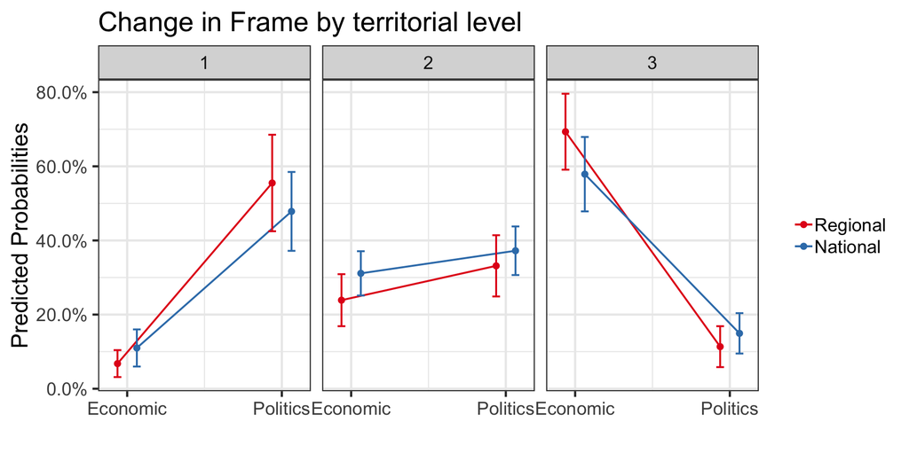

#### Frames * Net Payer

Here we can see the effect on the predicted probabilities of changing from an Economic frame to a Politics frame on the 3 levels of the Tone variable by focusing on the Net Payer interaction. This was one of the stronger effects.

This is a somewhat similar picture to level. Again, not much happening in the neutral category (2). However, for negative (1) and positive (3) the move to a Politics frames seems more likely to be negative for net receivers than for net payers. When looking at the politics frames, the net receivers have a lower likelihood of being positive.

It should be noted that these probabilities don’t reveal much; there’s a marginal difference between groups but they are all in similar ranges.

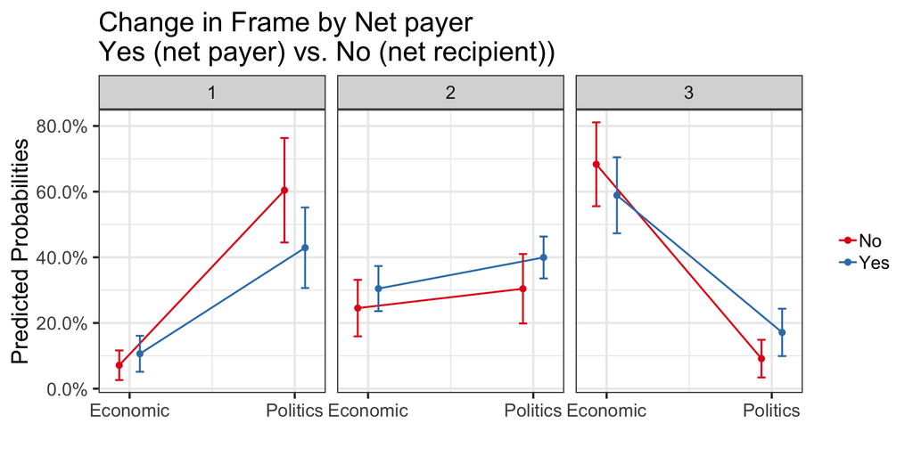

#### Frames * Words

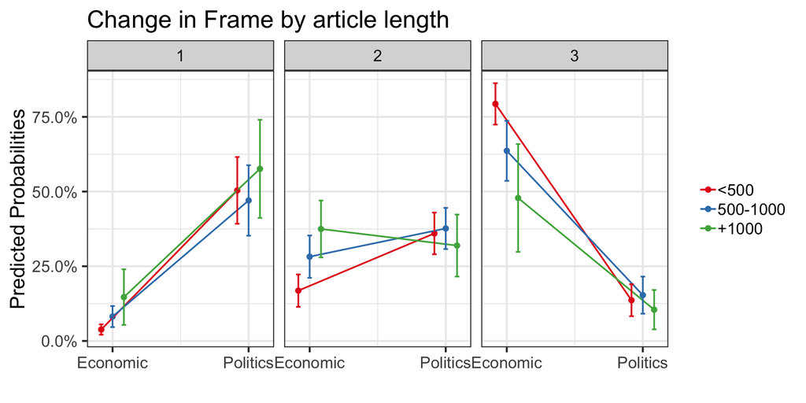

#### Frames * Visibility

Last interaction is the visbility one. It’s not clear what’s happening, and this is in any case not of much interest as a variable.

[figure not shown]

## Model 5 A quick check on an alternative

Let’s re-fit model 4 with country instead of Net Payer we’ll use the country variable to see how this is driving the results.

You can see how country is being driven by Spain.

```
Cumulative Link Mixed Model fitted with the Laplace approximation

formula: Tone ~ dim * (level + country + words + vis4) + (1 | country) +
    (1 | site)
data:    df

 link  threshold nobs logLik  AIC     niter       max.grad cond.H
 logit flexible  984  -764.93 1587.85 3567(10705) 6.23e-04 6.0e+02

Random effects:
 Groups  Name        Variance Std.Dev.
 site    (Intercept) 0.5979   0.7733
 country (Intercept) 0.0000   0.0000
Number of groups:  site 227,  country 8

Coefficients:
                            Estimate Std. Error z value Pr(>|z|)
dimPolitics                -3.919868   0.528739  -7.414 1.23e-13 ***
levelNational              -0.674088   0.268774  -2.508 0.012141 *
countryFrance              -0.253691   0.476814  -0.532 0.594689
countryGermany             -0.007546   0.544878  -0.014 0.988950
countryGreece               0.873154   0.484014   1.804 0.071233 .
countryItaly                0.560937   0.513033   1.093 0.274230
countryRomania              0.045760   0.487633   0.094 0.925236
countrySpain                2.639574   0.697705   3.783 0.000155 ***
countryUK                   1.497666   0.590500   2.536 0.011204 *
words500-1000              -0.896672   0.233637  -3.838 0.000124 ***
words+1000                 -1.645306   0.416364  -3.952 7.76e-05 ***
vis4.L                     -0.102967   0.219363  -0.469 0.638790
vis4.Q                      0.306141   0.186140   1.645 0.100035
dimPolitics:levelNational   0.878126   0.362610   2.422 0.015449 *
dimPolitics:countryFrance   1.498534   0.585035   2.561 0.010424 *
dimPolitics:countryGermany  0.628743   0.610515   1.030 0.303077
dimPolitics:countryGreece   0.285080   0.666044   0.428 0.668637
dimPolitics:countryItaly    0.192147   0.574052   0.335 0.737835
dimPolitics:countryRomania -0.574798   0.624055  -0.921 0.357014
dimPolitics:countrySpain   -2.960187   0.815875  -3.628 0.000285 ***
dimPolitics:countryUK       0.396042   0.686476   0.577 0.563993
dimPolitics:words500-1000   0.919362   0.331349   2.775 0.005527 **
dimPolitics:words+1000      1.174877   0.562915   2.087 0.036876 *
dimPolitics:vis4.L          0.438093   0.300978   1.456 0.145513
dimPolitics:vis4.Q         -0.241364   0.262001  -0.921 0.356929
---
Signif. codes:  0 '***' 0.001 '**' 0.01 '*' 0.05 '.' 0.1 ' ' 1

Threshold coefficients:
                 Estimate Std. Error z value
Negative|Neutral  -3.4088     0.4513  -7.553
Neutral|Positive  -1.2547     0.4320  -2.904
(1 observation deleted due to missingness)
```

When graphing the effects, you can clearly see the impact of Spain. Basically, on the positive tone Spain has virtually certain predicted probabilities for being or not being positive.

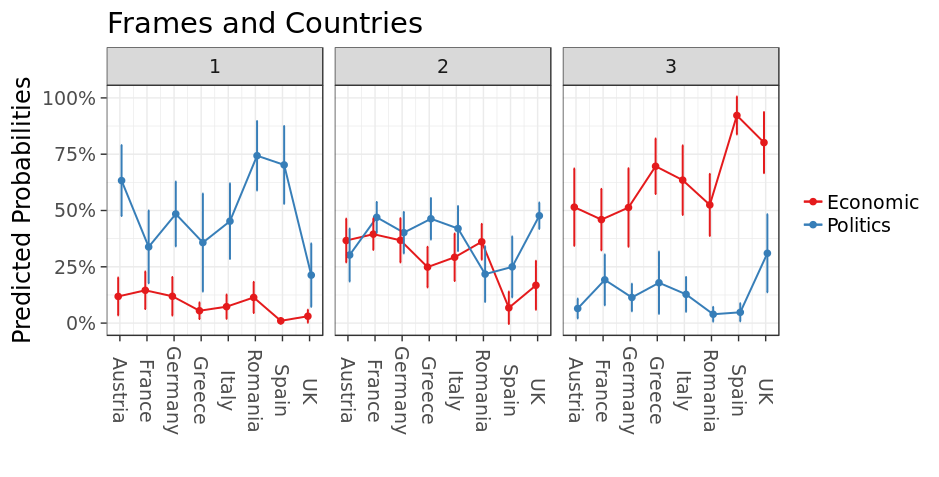

### Compare model 4 with model 5

Model 5 is significantly better than model 4.

```
## Likelihood ratio tests of cumulative link models:
##
##    formula:
## m4 Tone ~ dim * (level + NetPayer + words + vis4) + (1 | country)
## m5 Tone ~ dim * (level + country + words + vis4) + (1 | country) + (1 | site)
##    link: threshold:
## m4 logit flexible
## m5 logit flexible
##
##    no.par    AIC  logLik LR.stat df Pr(>Chisq)
## m4     16 1640.0 -803.99
## m5     29 1587.9 -764.93  78.122 13  2.485e-11 ***
## ---
## Signif. codes:  0 '***' 0.001 '**' 0.01 '*' 0.05 '.' 0.1 ' ' 1
```

# Summary

It’s easy to find significant coefficients in saturated regression models. The difficulty is making sense of them. Graphing helps here when interaction effects are at play. Yet in all these models the Frames overwhelm all others effects. The other significant factor is that country, or rather certain countries, matter.